# 3 simple ways to get your loan approved

Richard Kublik

May 09, 2017

# Introduction

In this project we will demonstrate a number of basic machine learning algorithms, and apply them to the [Loan Prediction practice competition](https://datahack.analyticsvidhya.com/contest/practice-problem-loan-prediction-iii/) offered by [Analytics Vidhya](https://www.analyticsvidhya.com/).

## The Problem

Dream Housing Finance company provides all types of home loans. They have a presence across all urban, semi-urban, and rural areas. Prior to the actual loan application, the company validates the customer’s eligibility for a loan.

Dream Housing Finance wants to automate the loan eligibility process, and provide a real time decision based on customer details provided through an online application form.

## The Data

Dream Housing Finance collects a number of customer details, These are provided in a .csv file with the columns:

| **Variable** | **Description** |
| --- | --- |
| Loan_ID | Unique Loan ID |
| Gender | Male/ Female |
| Married | Applicant married (Y/N) |
| Dependents | Number of dependents |
| Education | Applicant Education (Graduate/ Under Graduate) |
| Self_Employed | Self employed (Y/N) |
| ApplicantIncome | Applicant income |
| CoapplicantIncome | Coapplicant income |
| LoanAmount | Loan amount in thousands |
| Loan_Amount_Term | Term of loan in months |
| Credit_History | credit history meets guidelines |
| Property_Area | Urban/Semi Urban/Rural |
| Loan_Status | Loan approved (Y/N) |

# Pre-processing

As with most real world data sets, the loan data provided by Dream Housing Finance requires some initial cleanup prior to working with it. In particular, there are missing values that must be dealt with before any functional model can be created. We begin by loading the training data provided, and converting the character data types to factors.

```r
library(plyr)
library(dplyr)
library(readr)
library(caret)
library(rpart)
library(rattle)
library(rpart.plot)
library(RColorBrewer)
library(ranger)
library(e1071)
library(pROC)
library(randomForest)
library(glmnet)
library(ggmosaic)
library(ggbiplot)

pre_process <- function(data){
  data %>%
    mutate(Gender = factor(Gender),
           Married = factor(Married),
           Dependents = as.integer(gsub("+", "", Dependents, fixed = TRUE)),
           Education = factor(Education),
           Self_Employed = factor(Self_Employed),
           Credit_History = factor(Credit_History),
           Property_Area = factor(Property_Area),
           Loan_Amount_Term = factor(Loan_Amount_Term))
}
loan_data <- read_csv(file.path("..","data","train.csv")) %>%
  pre_process() %>%
  mutate(Loan_Status = factor(Loan_Status))
```

If we look at the summary statistics of the dataset, we find a number of variables have missing values:

```r
summary(loan_data)
```

```
   Loan_ID             Gender    Married      Dependents
 Length:614         Female:112   No  :213   Min.   :0.0000
 Class :character   Male  :489   Yes :398   1st Qu.:0.0000
 Mode  :character   NA's  : 13   NA's:  3   Median :0.0000
                                            Mean   :0.7629
                                            3rd Qu.:2.0000
                                            Max.   :3.0000
                                            NA's   :15
        Education   Self_Employed ApplicantIncome CoapplicantIncome
 Graduate    :480   No  :500      Min.   :  150   Min.   :    0
 Not Graduate:134   Yes : 82      1st Qu.: 2878   1st Qu.:    0
                    NA's: 32      Median : 3812   Median : 1188
                                  Mean   : 5403   Mean   : 1621
                                  3rd Qu.: 5795   3rd Qu.: 2297
                                  Max.   :81000   Max.   :41667

   LoanAmount    Loan_Amount_Term Credit_History   Property_Area
 Min.   :  9.0   360    :512      0   : 89       Rural    :179
 1st Qu.:100.0   180    : 44      1   :475       Semiurban:233
 Median :128.0   480    : 15      NA's: 50       Urban    :202
 Mean   :146.4   300    : 13
 3rd Qu.:168.0   84     :  4
 Max.   :700.0   (Other): 12
 NA's   :22      NA's   : 14
 Loan_Status
 N:192
 Y:422
```

For the categorical variables, we will impute the missing values with the most common value:

- **Gender:** 5/6ths of the applicants are male: impute NA’s with Male
- **Married:** 4/6ths are married: impute NA’s with Yes
- **Self_Employed:** 5/6ths are not self employed: impute NA’s with No
- **Loan_Amount_Term:** impute with median (360)
- **Credit_History:** 5/6ths have good credit: impute NA’s with 1

For the continuous variables, we will use some groupings to obtain more refined estimates of the missing values:

- **Dependents:** group by gender and marital status, and impute the NA’s with the median number of dependents within each group.
- **LoanAmount:** group by `Property_Area` and `Loan_Amount_Term` since it is likely that loan values will depend on the area and loan term.

We will use a simple function to impute these values.

```r
impute_value <- function(data, column, value){
  data[[column]][which(is.na(data[[column]]))] <- value
  return(data)
}

clean <- function(data){
  data %>%
    # Impute Categorical variables with the most common value
    impute_value("Gender", "Male") %>%
    impute_value("Married", "Yes") %>%
    impute_value("Self_Employed", "No") %>%
    impute_value("Loan_Amount_Term", 360) %>%
    impute_value("Credit_History", 1) %>%
    # Impute median number of dependents, by gender and marital status
    group_by(Gender, Married) %>%
    mutate(Dependents = ifelse(is.na(Dependents),
                               as.integer(median(Dependents, na.rm = TRUE)),
                               Dependents)) %>%
    ungroup() %>%
    # Impute mean loan amount, by property area and loan term length
    group_by(Property_Area, Loan_Amount_Term) %>%
    mutate(LoanAmount = ifelse(is.na(LoanAmount),
                               as.integer(mean(LoanAmount, na.rm = TRUE)),
                               LoanAmount)) %>%
    ungroup()
}
loan_data <- clean(loan_data)
```

# Data Exploration

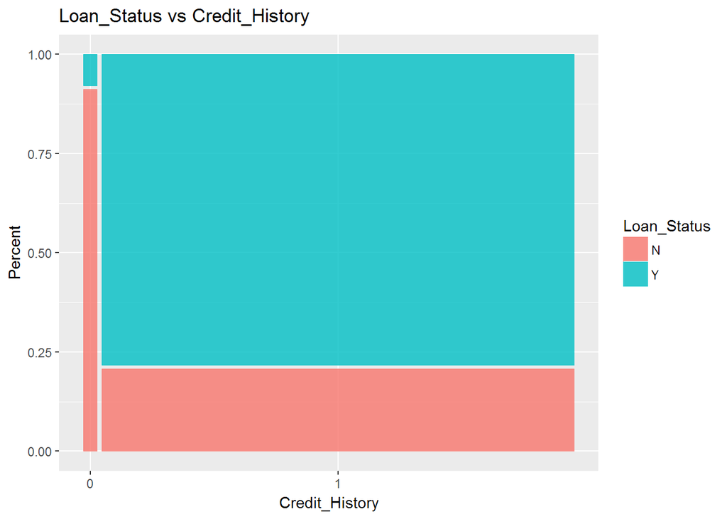

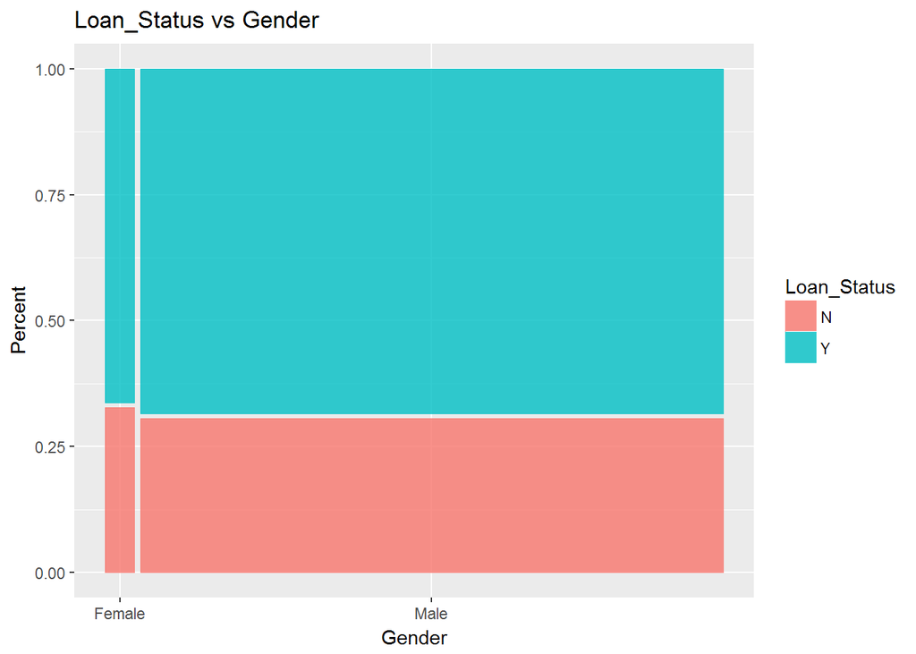

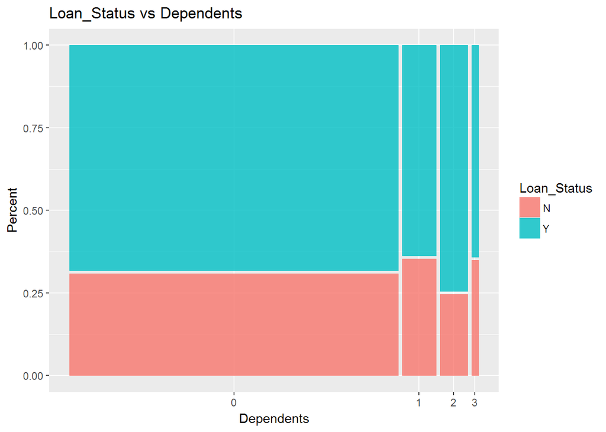

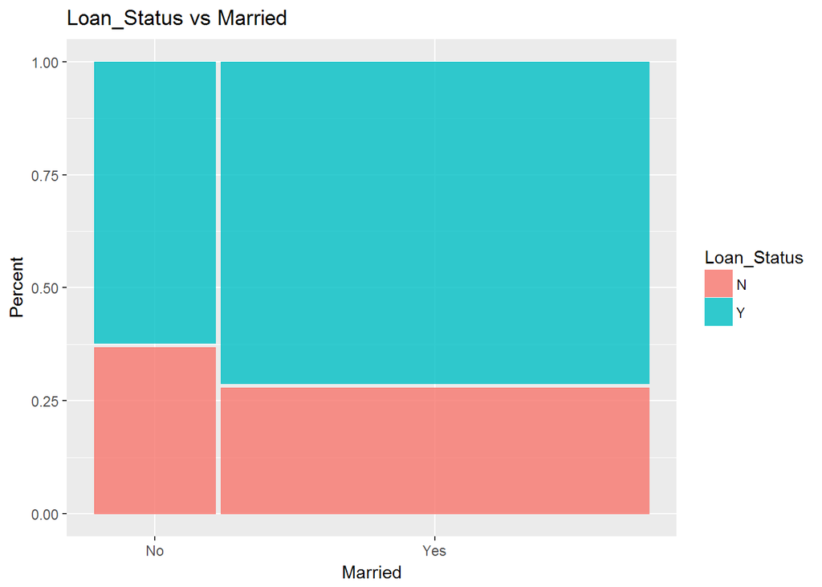

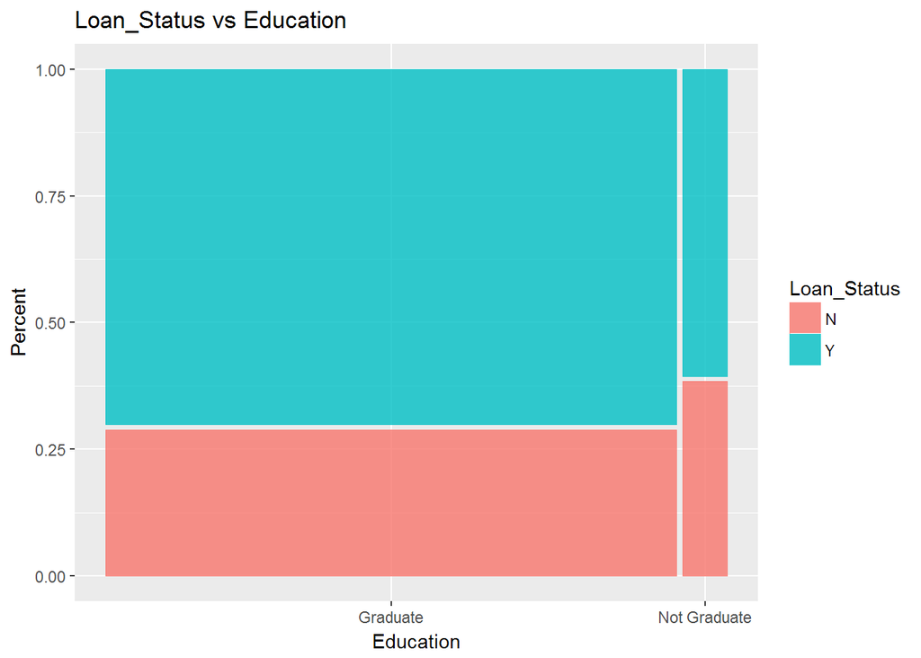

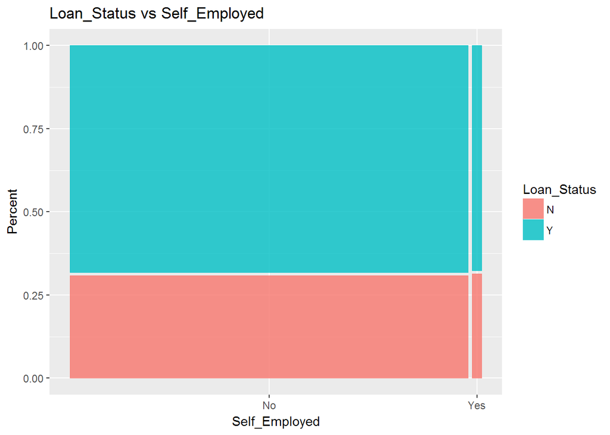

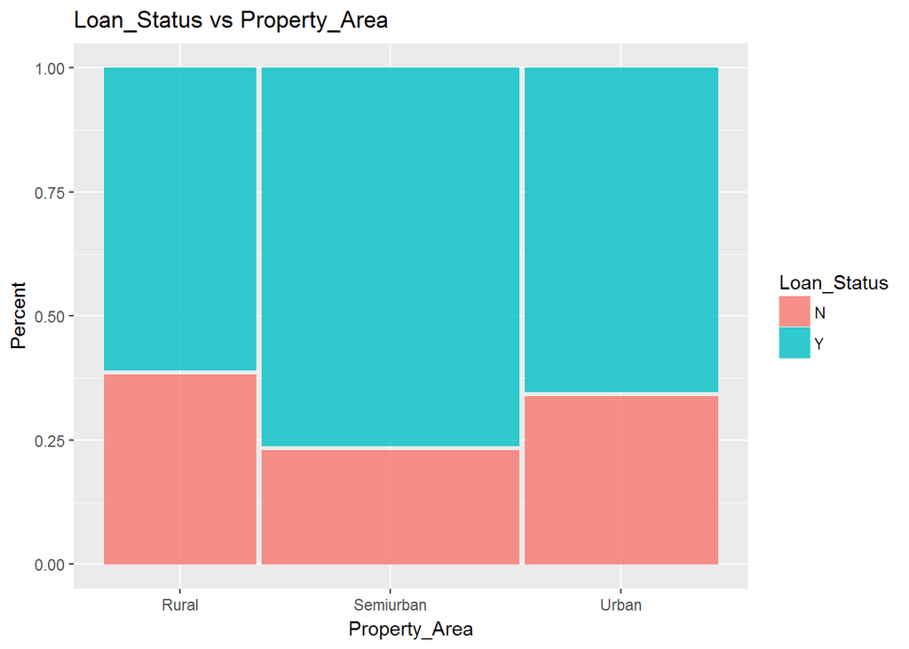

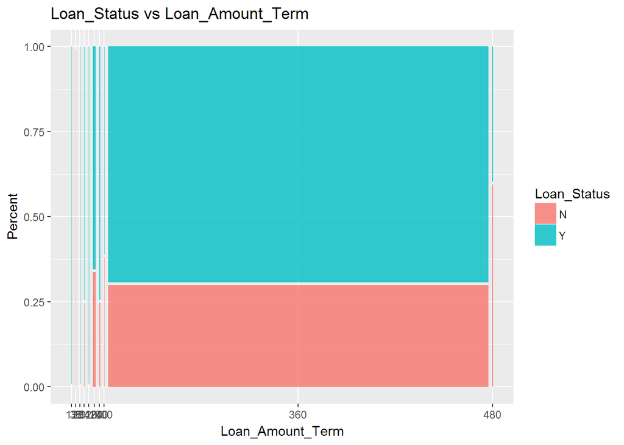

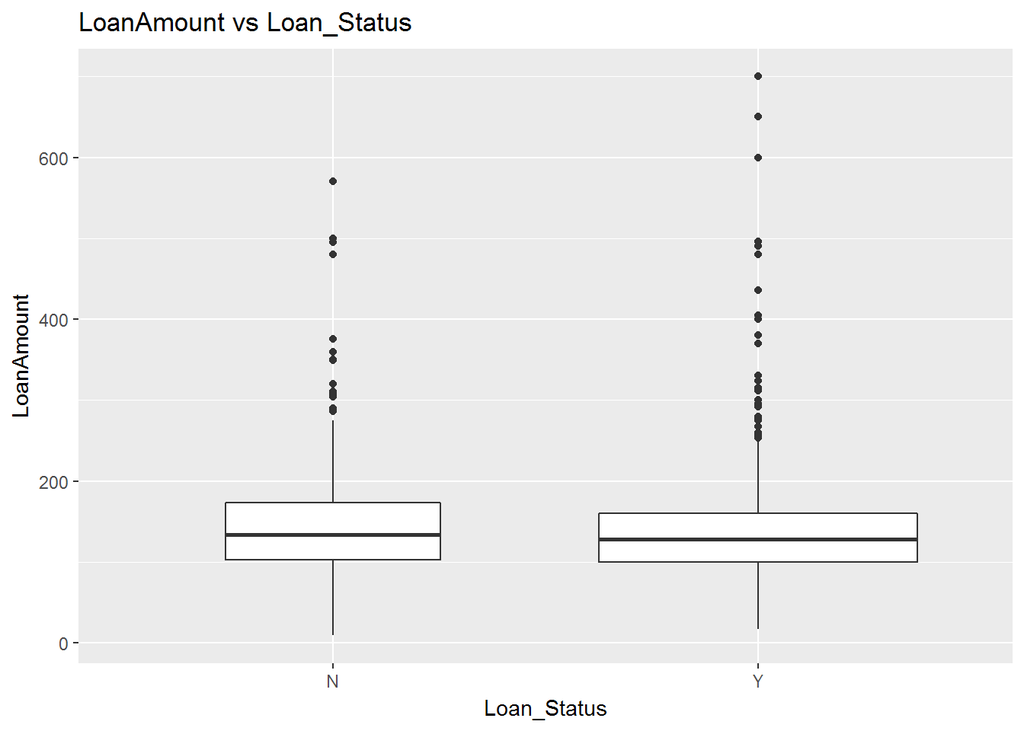

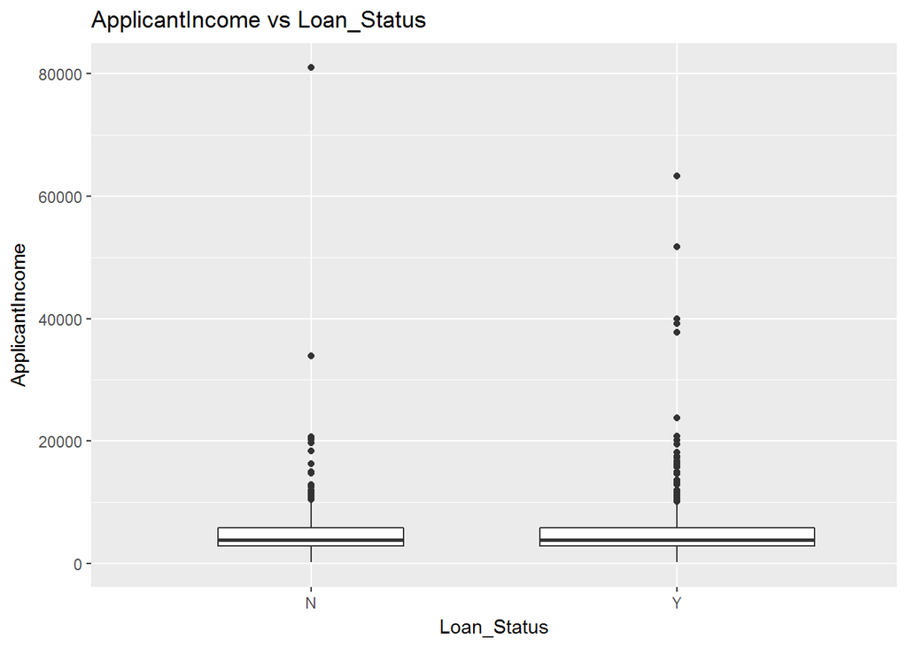

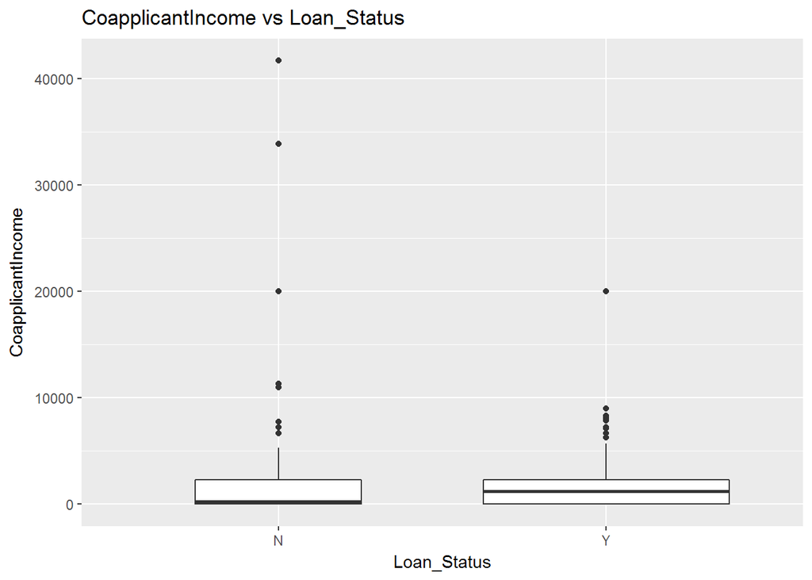

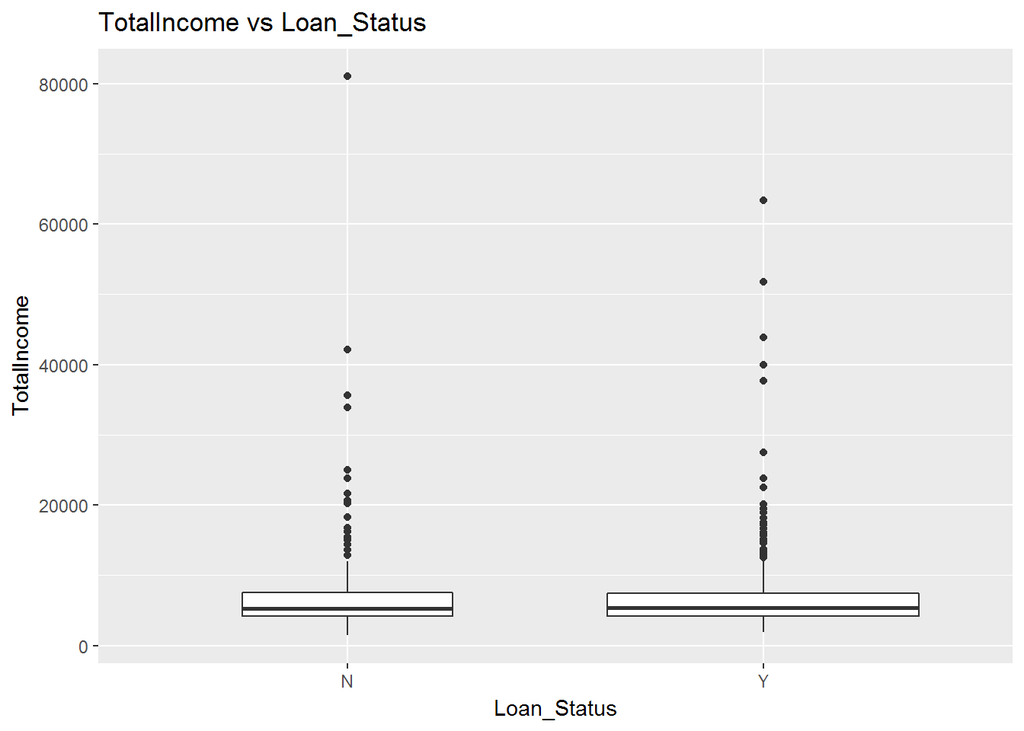

In the final plot, `TotalIncome` is a new variable computed as the sum of `ApplicantIncome` and `CoapplicantIncome`.

From the plots we can draw a number of conclusions:

- Credit history shows the most significant correlation with loan approval. We will include this in all of our models
- Marital status, Education level, and Property area appear to have a small correlation with loan approval
- The remaining variables do not appear to have any significant correlation with loan approval.

## Principal Component Ananlysis

In many cases, Principal Component Analysis (PCA) can provide some insight into the data. By plotting the data in PCA space we can potentially see clustering in the data, along with information about co-linearity of the variables. Plotting the PCA of the input variables, we obtain:

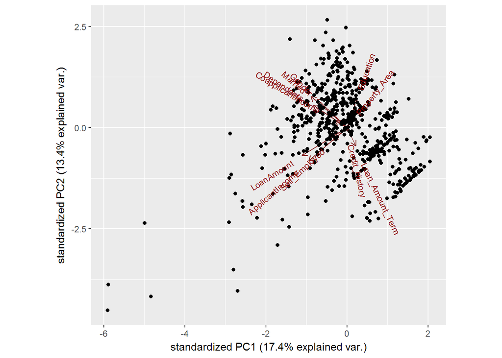

```r
train_pca <- loan_data %>%
  select(-Loan_ID, -Loan_Status) %>%
  # convert factors to numeric values
  mutate(Gender = as.numeric(Gender),
         Married = as.numeric(Married),
         Education = as.numeric(Education),
         Self_Employed = as.numeric(Self_Employed),
         Loan_Amount_Term = as.numeric(Loan_Amount_Term),
         Credit_History = as.numeric(Credit_History),
         Property_Area = as.numeric(Property_Area)) %>%
  # Calculate PCA
  prcomp(center = TRUE, scale = TRUE)

ggbiplot(train_pca)
```

This plot shows all of the data points in PCA space, and includes arrows mapping the variables to the 2 dimensional PCA space. Though the text is a bit difficult to read, we see that:

- `Married` and `Gender` are colinear
- `CoapplicantIncome` and `Dependents` are colinear
- `ApplicantIncome` and `Self_Employed` are colinear

Using this information we will be able to simplify the models that we build. Additionally, when we are building the logistic model, we will want to avoid having variables that are co-linear.

If we include the `Loan_Status` variable in our PCA, we notice something interesting.

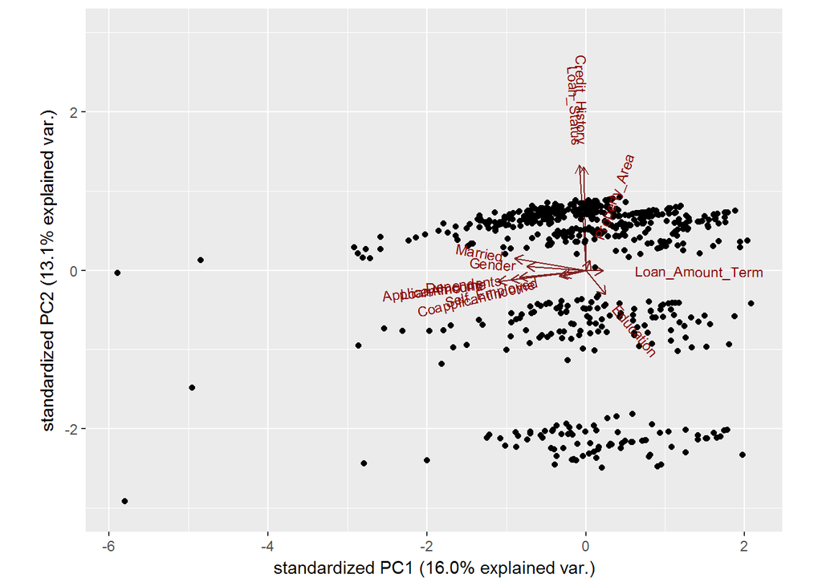

```r
train_pca <- loan_data %>%
  select(-Loan_ID) %>%
  # convert factors to numeric values
  mutate(Gender = as.numeric(Gender),
         Married = as.numeric(Married),
         Education = as.numeric(Education),
         Self_Employed = as.numeric(Self_Employed),
         Loan_Amount_Term = as.numeric(Loan_Amount_Term),
         Credit_History = as.numeric(Credit_History),
         Loan_Status = as.numeric(Loan_Status),
         Property_Area = as.numeric(Property_Area)) %>%
  # Calculate PCA
  prcomp(center = TRUE, scale = TRUE)

ggbiplot(train_pca) +
  lims(y = c(-3,3) )
```

We see that `Credit_History` is almost co-linear with `Loan_Status`. As a result, we expect that `Credit_History` will have the most impact on any predictive model we create.

# Predictive Models

Using the insight we have gained in the previous section, we will construct a number of predictive models and compare their performance. To insure a fair comparison, we will split the provided data into test and training sets and use these to evaluate how well our models do on unseen data. Using the `caret` package, we create `loan$train`, and `loan$test`:

```r
train_idx = createDataPartition(loan_data$Loan_Status, p = 0.7, list = FALSE)
loan = list(train = loan_data[train_idx,],
            test = loan_data[-train_idx,])
```

In addition, since the data was provided as part of an online competition, we can submit the results of our models to see how they compare to models developed by other people. We will pre-process the test data set using the functions we created earlier:

```r
loan_test_data <- read_csv(file.path("..","data","test.csv")) %>%
  pre_process() %>%
  clean()
```

## Credit History as Sole Predictor

From our earlier exploration, we saw that the `Credit_History` variable has the most obvious correlation with `Loan_Status`. For this initial attempt at a model, we will predict loan approval for all customers with `Credit_History = 1`. Applying this to our test partition

```r
credit_history_success <- loan$test %>%
  mutate(loan_approved = Loan_Status == "Y",
         credit_only = Credit_History == 1) %>%
  summarize(n = n(),
            success = sum(credit_only)/n)
```

If we apply this same technique to the provided test data and submit it to the competition (using the code provided below), we obtain an accuracy of 78% which puts us in 945th place (tied with 319 other people at the time of writing).

```r
loan_test_data %>%
  mutate(Loan_Status = ifelse(Credit_History == 1, "Y", "N")) %>%
  select(Loan_ID, Loan_Status) %>%
  write_csv(file.path("credit_only.csv"))
```

## Logistic Regression

For our logistic regression solution, we will include a few more variables. From our visual inspection of the variables, and the results of PCA, we will build a linear regression model that includes the variables: `Credit_History`, `Married`, `Education`, `Property_Area`. Using the `caret` package to do cross-validation, we train our model as shown below:

```r
# Define a common training control:
train_control <- trainControl(method = "repeatedcv",
                              number = 10,
                              repeats = 10,
                              summaryFunction = twoClassSummary,
                              classProbs = TRUE,
                              verboseIter = FALSE)

logit_model <- train(Loan_Status ~ Credit_History + Married + Education + Property_Area,
                   data = loan$train,
                   method = "glm",
                   metric = "ROC",
                   trControl = train_control,
                   family = binomial(link = "logit"))
```

```r
logit_pred <- predict(logit_model, loan$test, type = "prob")
logit_accuracy <- data.frame(loan_id = loan$test$Loan_ID,
                       loan_granted = loan$test$Loan_Status == "Y",
                       logit = logit_pred$Y > 0.5) %>%
  summarize(n = n(),
            accuracy = sum(logit == loan_granted)/n)

round(logit_accuracy$accuracy[1]*100)
```

```
[1] 84
```

we obtain an accuracy of 84%. We can also examine the variables included in the model to determine which are the most significant.

```r
summary(logit_model)$coefficients
```

```
                          Estimate Std. Error    z value     Pr(>|z|)
(Intercept)             -3.0558197  0.5241540 -5.8300033 5.542628e-09
Credit_History1          3.6156941  0.4637243  7.7970763 6.335795e-15
MarriedYes               0.3581173  0.2522152  1.4198879 1.556403e-01
`EducationNot Graduate` -0.1688527  0.3000104 -0.5628228 5.735556e-01
Property_AreaSemiurban   1.2526389  0.3202069  3.9119677 9.154714e-05
Property_AreaUrban       0.4365650  0.2909054  1.5007111 1.334303e-01
```

# Feature Engineering

Take a minute and go back to the Introduction, and look at the variables provided. At first glance, it appears that all the important data has been collected. We have information about the applicant’s income, the coapplicant’s income. We can compare the income to the loan amount, and check the applicant’s credit history. However, this doesn’t give a complete picture of the applicant’s financial status. There are a few other bits of information I think might be relevant:

- Assuming that the applicant and co-applicant will be making payments together, we will consider the total income. We previously looked at the total income and didn’t see a strong correlation with loan approval, but we will see that can be helpful shortly.
- Typically a bank would want assurances that the applicant will be able to make the monthly payments, and requests information about the applicant’s regular expenses. We aren’t given this information, but can create a proxy for it by assuming that total expenses are proportional to the number of people in the household.
- Finally we will include the ratio of the loan amount to total income. We would naively expect that a lower ratio would be more likely to be approved.

We augment our data set with these new variables:

```r
new_features <- function(data){
  data %>%
    mutate(TotalIncome = ApplicantIncome + CoapplicantIncome,
           HouseholdSize = 1 + as.numeric(Married == "Yes") + Dependents,
           LoanRatio = LoanAmount / TotalIncome)
}

loan_data <- new_features(loan_data)
```

## Data Exploration:

To quickly check the influence of our new variables, we will make a plot of the PCA:

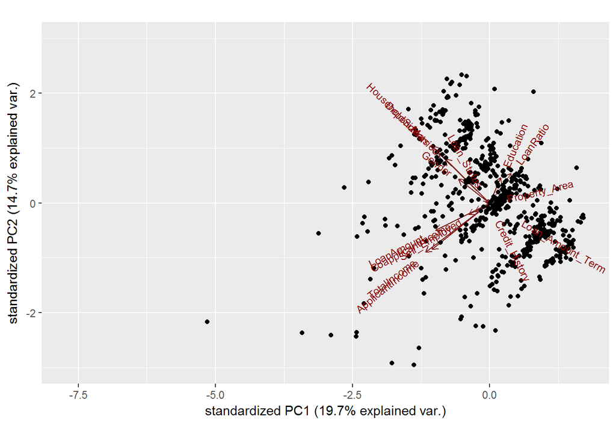

```r
#library(ggbiplot)

train_pca <- loan_data %>%
  select(-Loan_ID) %>%
  # convert factors to numeric values
  mutate(Gender = as.numeric(Gender),
         Married = as.numeric(Married),
         Education = as.numeric(Education),
         Self_Employed = as.numeric(Self_Employed),
         Loan_Amount_Term = as.numeric(Loan_Amount_Term),
         Credit_History = as.numeric(Credit_History),
         Loan_Status = as.numeric(Loan_Status),
         Property_Area = as.numeric(Property_Area)) %>%
  # Calculate PCA
  prcomp(center = TRUE, scale = TRUE)

ggbiplot(train_pca) +
  lims(y = c(-3,3) )
```

By adding these new variables, we have eliminated the close association between `Credit_History` and `Loan_Status`. In the plots below, we will explore the single-variable influence of our new variables on `Loan_Status`.

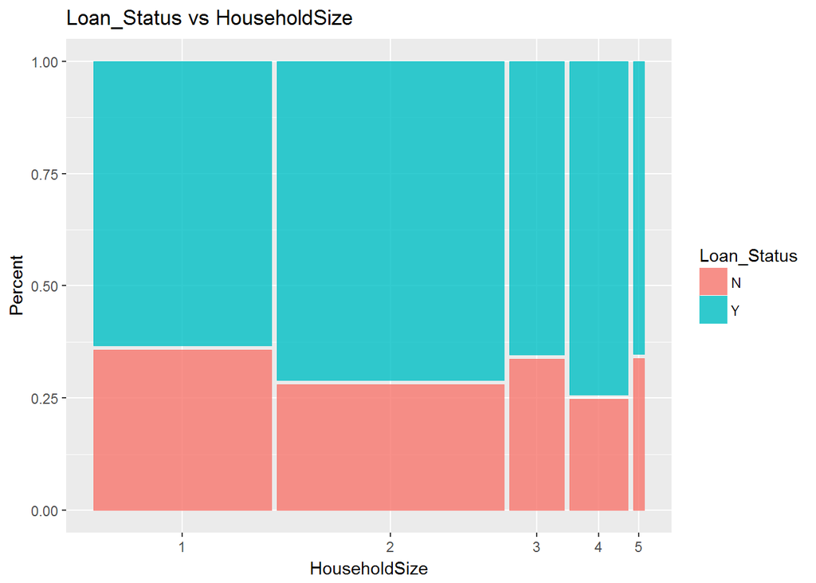

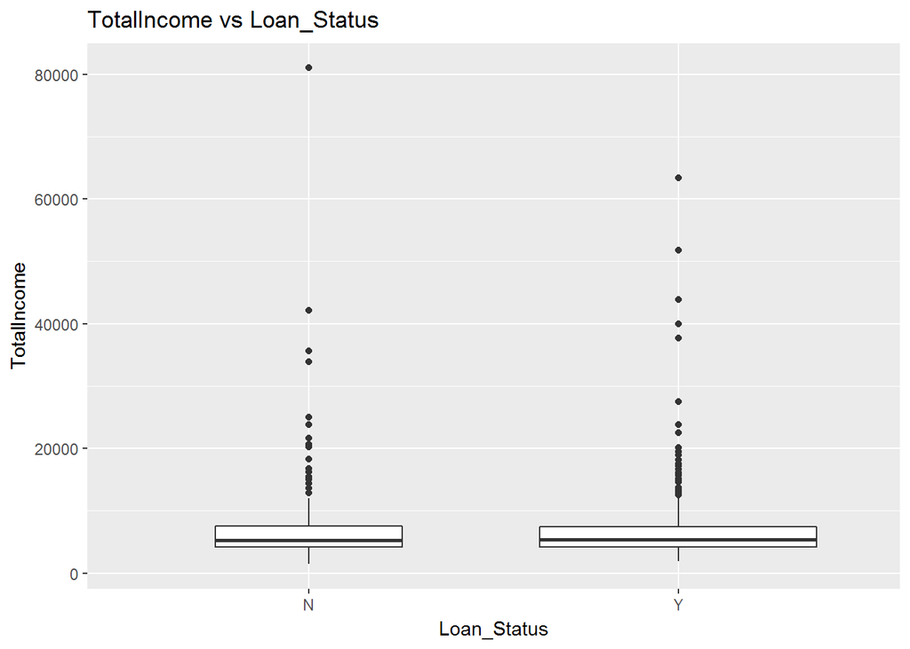

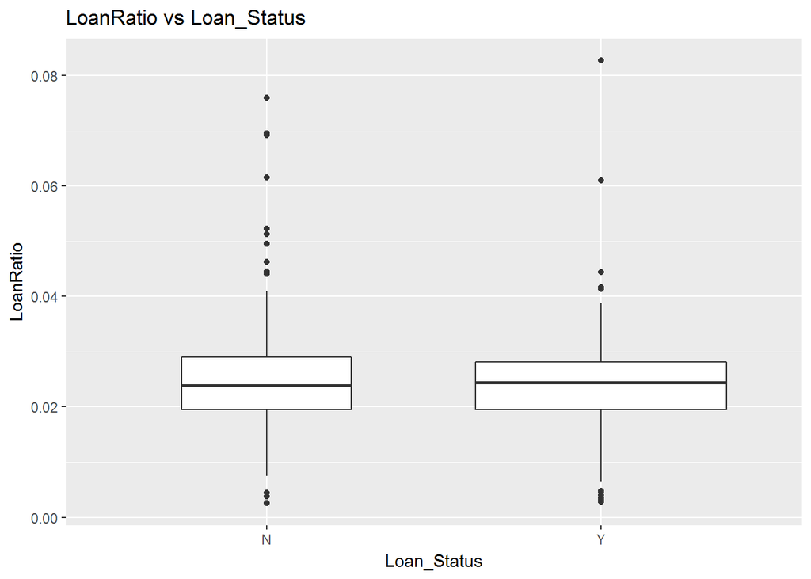

While these variables don’t appear to have much influence indivually, we will include them due to their effect on the PCA.

# Predictive Modeling: Take 2

We know that including too many variables in a model can lead to over-fitting, and poor performance on new data. Let’s look at a model that only contains the two most important variables. Following the same steps as above, we will train and test a reduced logistic model.

```r
logit_reduced_model <- train(Loan_Status ~ Credit_History  + Property_Area,
                   data = loan$train,
                   method = "glm",
                   metric = "ROC",
                   trControl = train_control,
                   family = binomial(link = "logit"))
logit_reduced_pred <- predict(logit_reduced_model, loan$test, type = "prob")
logit_reduced_accuracy <- data.frame(loan_id = loan$test$Loan_ID,
                       loan_granted = loan$test$Loan_Status == "Y",
                       logit = logit_reduced_pred$Y > 0.5) %>%
  summarize(n = n(),
            accuracy = sum(logit == loan_granted)/n)
summary(logit_reduced_model)$coefficients
```

```
                         Estimate Std. Error   z value     Pr(>|z|)
(Intercept)            -2.9052179  0.4883882 -5.948584 2.704725e-09
Credit_History1         3.6284852  0.4620323  7.853315 4.051823e-15
Property_AreaSemiurban  1.2796569  0.3188993  4.012730 6.002049e-05
Property_AreaUrban      0.4733741  0.2867841  1.650629 9.881431e-02
```

```r
round(logit_reduced_accuracy$accuracy[1]*100)
```

```
[1] 84
```

```r
logit_submission_model <- train(Loan_Status ~ Credit_History  + Property_Area,
                   data = loan_data,
                   method = "glm",
                   metric = "ROC",
                   trControl = train_control,
                   family = binomial(link = "logit"))

logit_submission_pred <- predict(logit_reduced_model, loan_test_data, type = "prob")
data.frame(Loan_ID = loan_test_data$Loan_ID,
           Loan_Status = ifelse(logit_submission_pred$Y > 0.5, "Y", "N")) %>%
    write_csv(file.path("logistic_regression.csv"))
```

When we submit this result, our reported accuracy is again 78%. It seems that Logistic regression isn’t the right approach for this problem.

## Decision Tree

We will again take the varibles determined to be the most important and use them in our decision tree model. Again, we will utilize the `caret` package to perform the cross validation on our model.

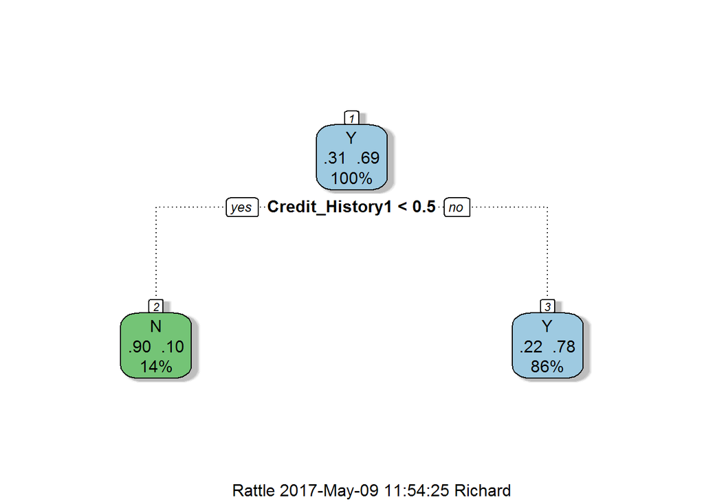

```r
rpart_model <- train(#Loan_Status ~ Credit_History + Married + Dependents + Education + ApplicantIncome + CoapplicantIncome + LoanAmount + Property_Area,
                     Loan_Status ~ Credit_History + Married + Education + Property_Area,
                     data = loan$train,
                     method = "rpart",
                     metric = "ROC",
                     trControl = train_control)
```